# Processing Georeferenced Sanborn Maps for Polygonizable Rasters v. 1.0.0 by Parker Otto

Created as part of the Roaring '20s Chicago Research Project.

Mean 4k image total processing time: 42 seconds.

Features under development: GUI and Web Application; Initial removal of black pixels for cleaner outputs; Tidied variable names; Outputting initial TIF without background pixels; Identification and removal of redundent processes; Academic research article focusing on use for large-scale Sanborn digitization projects.

## Example Map

For this code, I will use a Chicago Sanborn Fire Insurance Map from the Chicago Public Library (retrieved via Fire Insurance Maps Online).

The map is Sheet 10 from Chicago Volume 16. The initial JPEG image was georeferenced with the Freehand Raster Georeferencer plugin in QGIS and exported as a TIF. The image is 5615 × 8263 pixels.

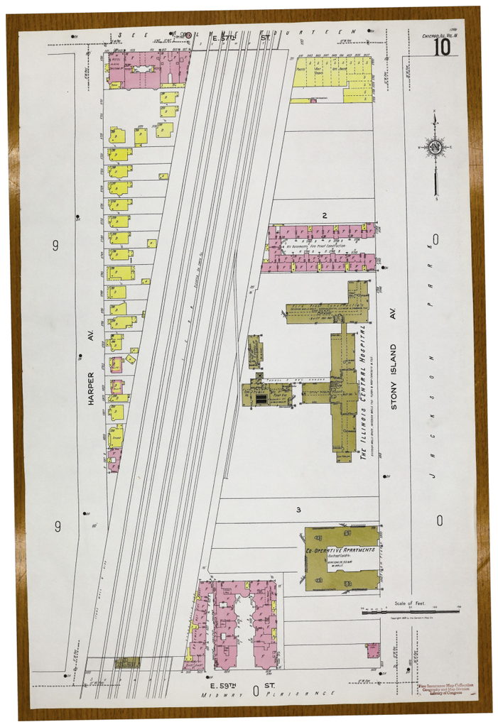

```python
import matplotlib.pyplot as plt
import matplotlib.image as mpimg
img = mpimg.imread('tifs/1610hrt.tif')
plt.figure(figsize=(18, 16))
plt.axis('off')
imgplot = plt.imshow(img)
plt.show()
```

## Step 1

Input a high-resolution georeferenced TIF (5615 × 8263 was used for this project).

Identifies white, gray, and beige pixels as background.

Threshold variables (white_threshold, gray_threshold, beige_threshold) can be adjusted at will to decrease noise.

Creates a binary mask to separate background from not background (ideally, building footprints, but realistically also a bit of noise).

Uses multidimensional binary erosion (from Scipy Multidimensional Image Processing) to remove noise (small clumps of black pixels).

Uses 3 iterations of binary dilation (from Scipy Multidimensional Image Processing) to maximize white space (to preserve some small gaps between buildings, while removing more nosie).

Outputs a georeferenced TIF with black footprints and background.

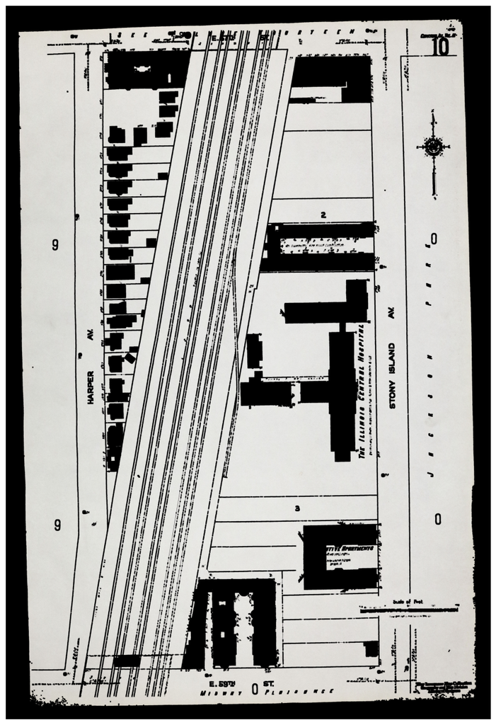

```python
import rasterio
import numpy as np
from scipy.ndimage import binary_erosion, binary_dilation
import matplotlib.pyplot as plt

### Open the input file
input_file = "tifs/1610hrt.tif"
output_file = "output.tif"

### Define thresholds for white, gray, and beige pixels
white_threshold = 260
gray_threshold = 200
beige_threshold = 182

### Define the minimum area for regions to be preserved
min_region_area = 100

with rasterio.open(input_file) as src:
    ### Read image data
    img_data = src.read()

    ### Convert to 8-bit unsigned integer
    img_data = img_data.astype('uint8')

    ### Check the band count and shape
    num_bands, height, width = img_data.shape

    ### Iterate through each pixel and check if it's white, gray, or beige
    wPx = (img_data[0] >= white_threshold) & (img_data[1] >= white_threshold) & (img_data[2] >= white_threshold)
    gPx = ((img_data[0] >= gray_threshold) & (img_data[0] < white_threshold)) & \
                  ((img_data[1] >= gray_threshold) & (img_data[1] < white_threshold)) & \
                  ((img_data[2] >= gray_threshold) & (img_data[2] < white_threshold))
    bPx = ((img_data[0] >= beige_threshold) & (img_data[0] < gray_threshold)) & \
                   ((img_data[1] >= beige_threshold) & (img_data[1] < gray_threshold)) & \
                   ((img_data[2] >= beige_threshold) & (img_data[2] < gray_threshold))

    ### Create a binary mask indicating where pixels aren't white, gray, or beige (i.e. footprints and noise)
    bgPx = ~wPx & ~gPx & ~bPx

    ### Perform binary erosion to remove small clusters of black pixels (noise)
    structuring_element = np.ones((5, 5), dtype=bool)  # Adjust structuring element size as needed
    eroded_mask = binary_erosion(bgPx, structure=structuring_element)

    ### Perform multiple iterations of binary dilation to maximize areas classified as background (set to white)
    structuring_element = np.ones((5, 5), dtype=bool)  # Adjust structuring element size as needed
    dilation_iterations = 3  # Increase the number of iterations for more preference to white
    dilated_mask = eroded_mask.copy()
    for _ in range(dilation_iterations):
        dilated_mask = binary_dilation(dilated_mask, structure=structuring_element)

    ### Create a new image with only background pixels and preserved larger structures
    processed_img_data = img_data.copy()
    processed_img_data[:, dilated_mask] = 0  # Set black pixels in the processed regions to 0

    ### Ensure the image data has 3 bands
    if processed_img_data.shape[0] != 3:
        processed_img_data = processed_img_data[:3]  # Keep only the first 3 bands

    ### Create output file
    profile = src.profile
    profile.update(count=3, dtype='uint8')  # Update profile for 3 bands and uint8 dtype

    with rasterio.open(output_file, 'w', **profile) as dst:
        # Write the processed image data to the output file
        dst.write(processed_img_data)

### Preview
plt.figure(figsize=(18, 16))  #Preview h/w
plt.imshow(processed_img_data.transpose(1, 2, 0))  # Transpose the image data for correct display
plt.axis('off')
plt.show()
```

## Step 2

Tidy up image and remove parcel lines.

Attempts to separate background (gray, beige, white pixels) from foreground (building footprints) by definding foreground element size and threshold for separating each element from the background with another binary mask.

Also defines line removal size (which can be adjusted depending on how thick parcel lines or other undesired line features are in your data by changing line_removal_element_size).

Uses multidimensional binary erosion and Binary Opening (from Scipy Multidimensional Image Processing) to remove small lines and isolated non-building clusters.

A filtered mask is then used to filter out small clusters of black pixels (collections smaller than 130px) to get rid of more noise and any remaining parcel boundaries, small writing/letters, etc.

Finally, a new georeferenced TIF is created. This can be uploaded into QGIS for polygonization and post-processing to create building footprints.

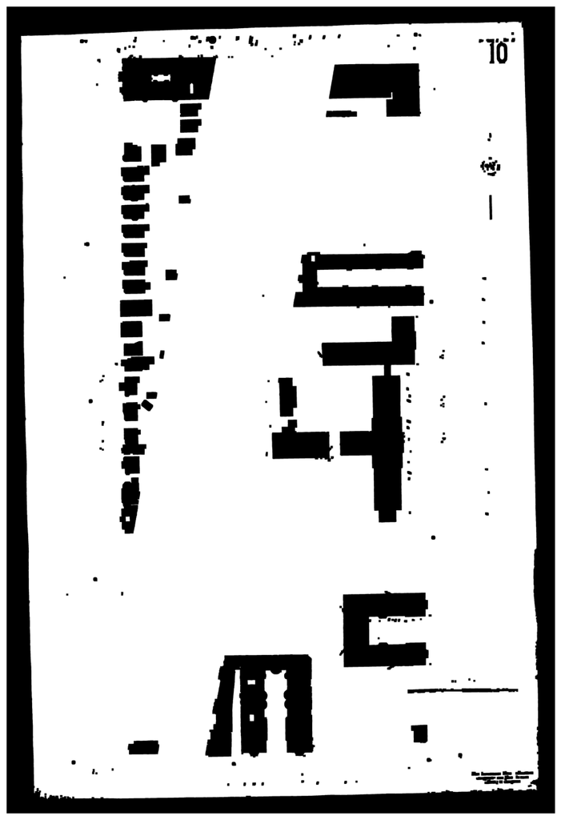

```python
import rasterio
import numpy as np
from scipy.ndimage import binary_erosion, binary_opening, label

### Open input file
input_file = "output.tif"
output_file = "cleaned.tif"

### Define thresholds for separating foreground from background
foreground_threshold = 25  # Adjust as needed

### Define the size of the structuring element for morphological operations
structuring_element_size = 3

### Define the size of the structuring element for thin lines removal
line_removal_element_size = 20  # Adjust this based on the thickness of the lines

with rasterio.open(input_file) as src:
    ### Read image data
    img_data = src.read()

    ### Convert to 8-bit unsigned integer
    img_data = img_data.astype('uint8')

    ### Check the band count and shape
    num_bands, height, width = img_data.shape

    ### Thresholding to separate foreground (building footprints and thin lines) from background (things that aren't that)
    foreground_mask = (img_data[0] <= foreground_threshold) & \
                      (img_data[1] <= foreground_threshold) & \
                      (img_data[2] <= foreground_threshold)

    ### Binary erosion to remove thin lines and small, isolated regions
    structuring_element = np.ones((structuring_element_size, structuring_element_size), dtype=bool)
    eroded_mask = binary_erosion(foreground_mask, structure=structuring_element)

    ### Binary opening to remove thin lines
    line_removal_element = np.ones((line_removal_element_size, line_removal_element_size), dtype=bool)
    opened_mask = binary_opening(eroded_mask, structure=line_removal_element)

    ### Label connected components (black pixel clusters)
    labels, num_features = label(opened_mask)

    ### Filter out parcel boundaries while keeping building footprints
    filtered_mask = np.zeros_like(opened_mask, dtype=bool)
    for i in range(1, num_features + 1):
        if np.sum(labels == i) > 130:  # Adjust minimum area threshold
            filtered_mask |= labels == i

    ### Create new image with only building footprints
    building_footprints_img = img_data.copy()
    building_footprints_img[:, ~filtered_mask] = 255  # Set non-building footprint pixels to white

    ### Ensure the image data has 3 bands
    if building_footprints_img.shape[0] != 3:
        building_footprints_img = building_footprints_img[:3]  # Keep only the first 3 bands

    ### Create output file
    profile = src.profile
    profile.update(count=3, dtype='uint8')  # Update profile for 3 bands and uint8 dtype

    with rasterio.open(output_file, 'w', **profile) as dst:
        ### Write image data to output file
        dst.write(building_footprints_img)
    plt.figure(figsize=(18, 16))  # Map size w/h
    plt.imshow(building_footprints_img.transpose(1, 2, 0))  # Transpose the image data for correct display
    plt.axis('off')
    plt.show()
```